# STA120 Exercises 3

Jan Hohenheim

3/7/2022

## Problem 8

In this problem we visualize and derive some properties of the Poisson random variable with parameter $\lambda > 0$

### a)

Visualize in R the cdf and pmf of X ~ Pois($\lambda$), for $\lambda = 1$ and $\lambda = 5.5$

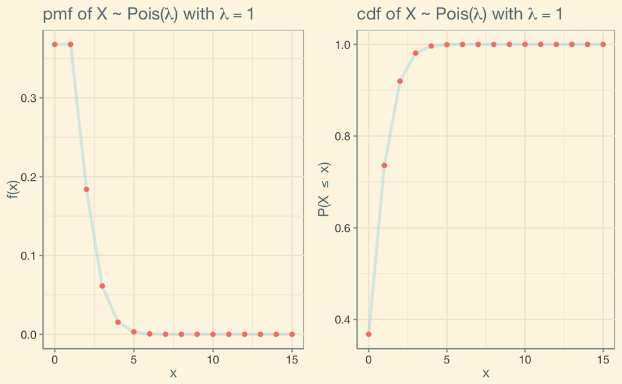

```r
plot_lambda <- function(lambda) {
  n <- 15
  x <- 0:n
  pmf <- x |>
    map_dbl(dpois, lambda)

  cdf <- x |>
    map_dbl(ppois, lambda)

  pmf_plot <- data.frame(x, probability = pmf) |>
    ggplot(aes(x = x, y = probability)) +
    geom_line(colour = "skyblue", alpha = 0.3, size = 1.2) +
    geom_point(colour = "salmon") +
    labs(title = TeX(glue("pmf of X ~ Pois($\\lambda$) with $\\lambda = {lambda}$")),
         x = "x",
         y = "f(x)") +
    theme

  cdf_plot <- data.frame(x, cummulative_probability = cdf) |>
    ggplot(aes(x = x, y = cummulative_probability)) +
    geom_line(colour = "skyblue", alpha = 0.3, size = 1.2) +
    geom_point(colour = "salmon") +
    labs(title = TeX(glue("cdf of X ~ Pois($\\lambda$) with $\\lambda = {lambda}$")),
         x = "x",
         y = TeX("P(X $\\leq$ x)")) +
    theme

  plot_grid(pmf_plot, cdf_plot)
}
plot_lambda(1)
```

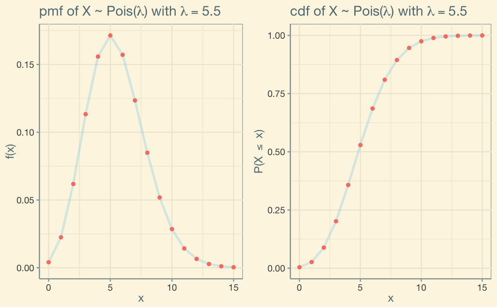

```r
plot_lambda(5.5)
```

### b)

For $\lambda = 1$ and $\lambda = 5.5$, sample from X1, … , $X_n$ ~ Pois($\lambda$) with n = 200 and draw histograms. Compare the histograms with a). What do you expect to happen when n increases?

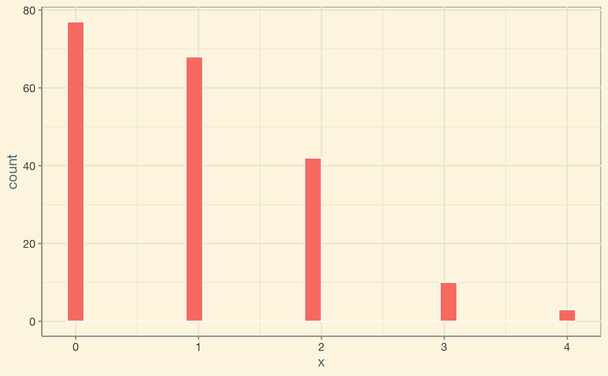

```r
plot_pois_hist <- function(lambda){
  n <- 200
  plot <- data.frame(x = rpois(n, lambda)) |>
    ggplot(aes(x = x)) +
    geom_histogram(fill = "salmon", bins = 30, color = "white") +
    theme
  plot
}
plot_pois_hist(1)
```

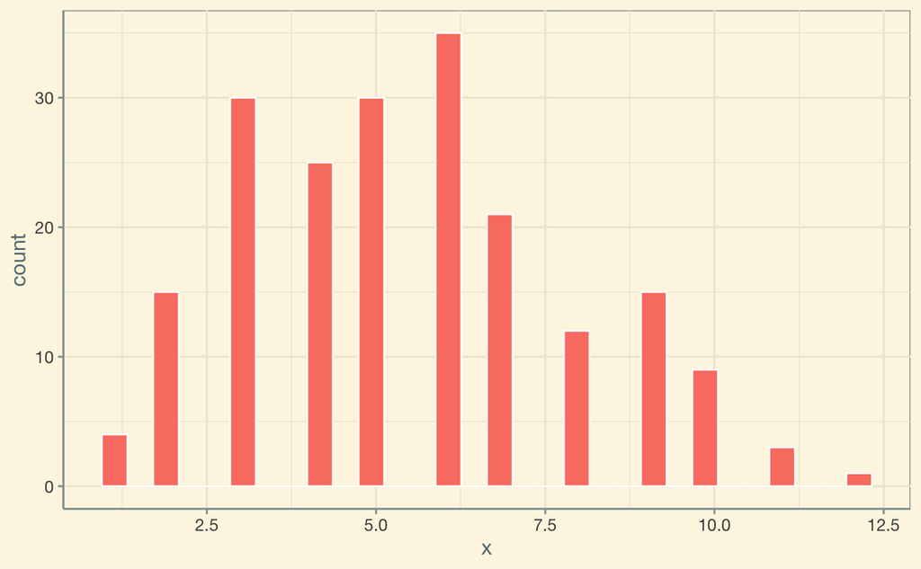

```r
plot_pois_hist(5.5)
```

These plots will approach the pmfs with higher n

### c)

Let X ~ Pois($\lambda$), with $\lambda$ = 3: calculate P(X $\leq$ 2), P(X < 2) and P(X $\geq$ 3)

```r
lambda = 3

p1 <- ppois(2, lambda)
glue("P(X <= 2) = {p1}")
```

```
P(X <= 2) = 0.423190081126844
```

```r
p2 <- ppois(1, lambda)
glue("P(X < 2) = P(X <= 1) = {p2}")
```

```
P(X < 2) = P(X <= 1) = 0.199148273471456
```

```r
p3 <- ppois(2, lambda, lower.tail = FALSE)
glue("P(X >= 3) = P(X > 2) = {p3}")
```

```
P(X >= 3) = P(X > 2) = 0.576809918873156
```

### d)

Plot the pmf of X ~ Pois($\lambda$), $\lambda$ = 5, and Y ∼ Bin(n, p) for n = 10, 100, 1000 with $\lambda$ = np. What can you conclude?

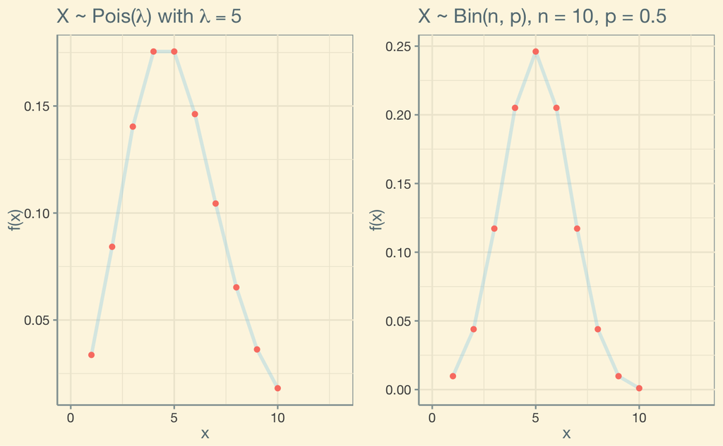

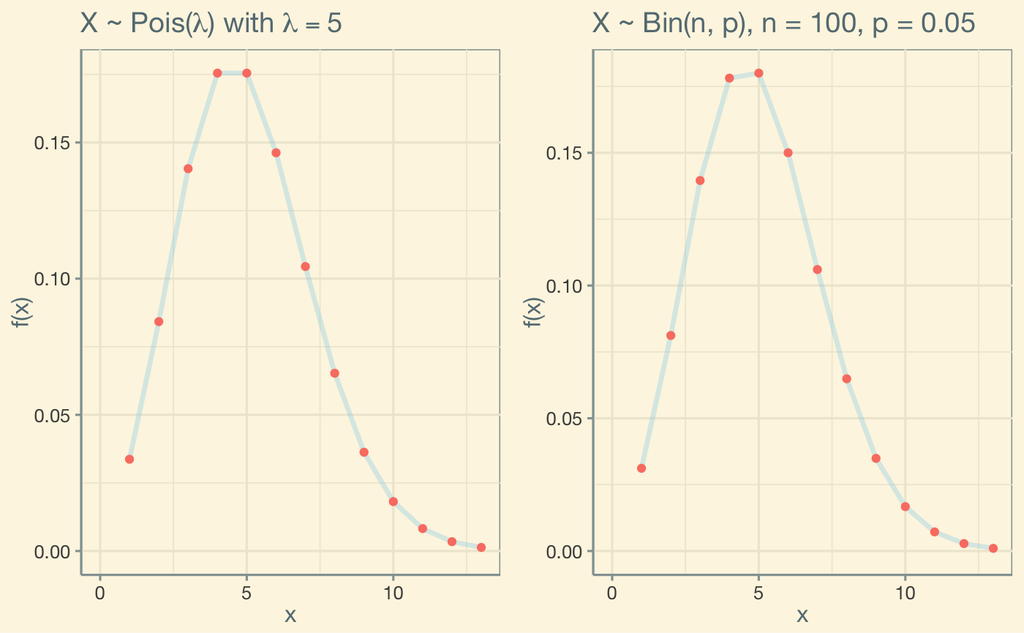

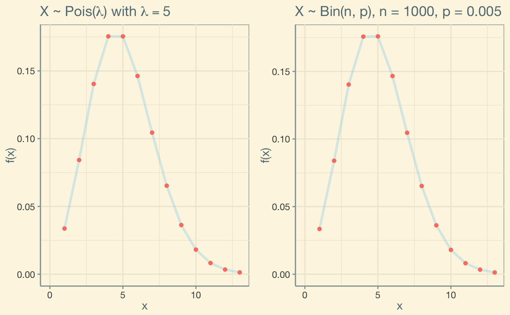

```r
plot_pmfs <- function(n) {
  x <- 1:n
  lambda <- 5
  pois_pmf <- x |>
    map_dbl(dpois, lambda = lambda)
  p <- lambda / n
  bin_pmf <- x |>
    map_dbl(dbinom, size = n, prob = p)
  plot_pois <- data.frame(x = x, probability = pois_pmf) |>
    ggplot(aes(x = x, y = probability)) +
    geom_line(colour = "skyblue", alpha = 0.3, size = 1.2) +
    geom_point(color = "salmon") +
    labs(title = TeX(glue("X ~ Pois($\\lambda$) with $\\lambda = {lambda}$")),
         x = "x",
         y = "f(x)") +
    xlim(0, 13) +
    theme
  plot_binom <- data.frame(x = x, probability = bin_pmf) |>
    ggplot(aes(x = x, y = probability)) +
    geom_line(colour = "skyblue", alpha = 0.3, size = 1.2) +
    geom_point(color = "salmon") +
    xlim(0, 13) +
      labs(title = TeX(glue("X ~ Bin(n, p), n = {n}, p = {p}")),
         x = "x",
         y = "f(x)") +
    theme
  plot_grid(plot_pois, plot_binom)
}

ns <- c(10, 100, 1000)
lapply(ns, plot_pmfs)
```

## Problem 10

Let X1, … , $X_n$ be independent and identically distributed (iid) random variables following Exp($\lambda$). Assume $\lambda$ = 2 for the following.

### a)

Sample n = 100 random numbers from Exp($\lambda$). Visualize the data with a histogram and superimpose the theoretical density.

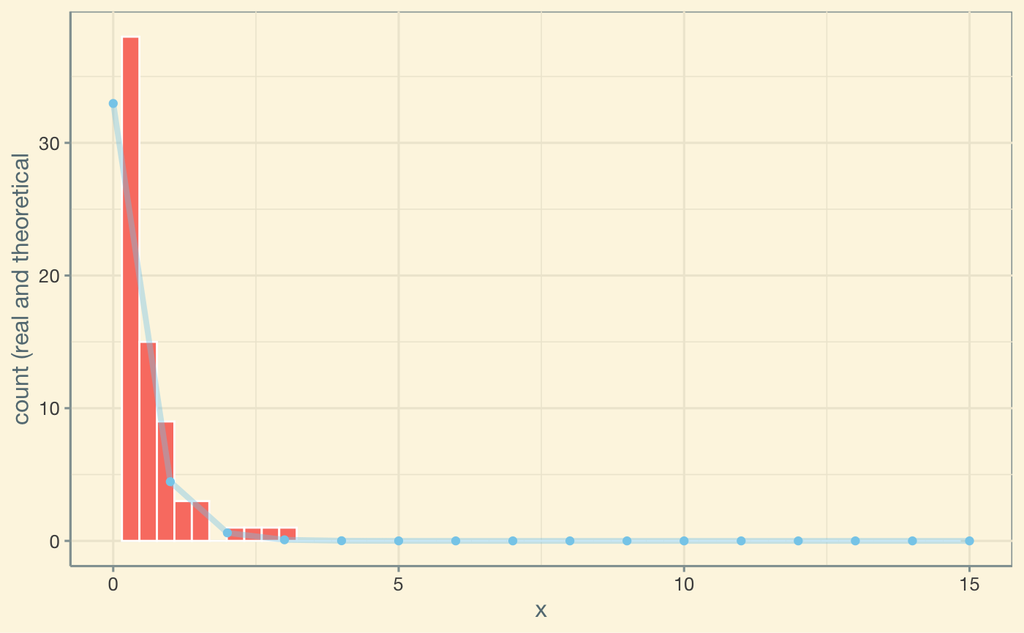

```r
n <- 100
lambda <- 2
sample = rexp(n, lambda)

x <- 0:(n - 1)
delta <- 0.2
theoretical <- x |>
  map_dbl(\(x) pexp(x + delta, lambda) - pexp(x, lambda)) * n


plot <-
  data_frame(x = x, sample = sample, theoretical = theoretical) |>
  ggplot() +
  geom_histogram(aes(x = sample), bins = 50, fill = "salmon", color = "white") +
  geom_point(aes(x = x, y = theoretical), colour = "skyblue") +
  geom_line(aes(x = x, y = theoretical), colour = "skyblue", size = 1.4, alpha = 0.4) +
  xlim(0, 15) +
  labs("X ~ Exp(2), sample and theory",
       x = "x",
       y = "count (real and theoretical") +
  theme
plot
```

### c)

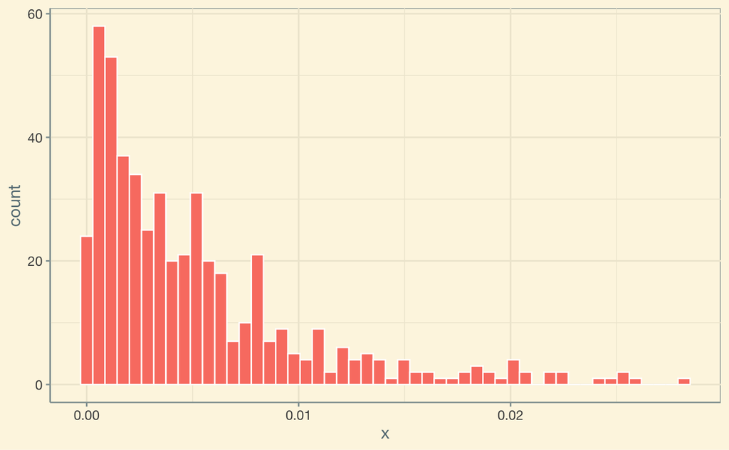

```r
lambda <- 2
n <- 100
m <- 500
sample <- 1:m |>
  map_dbl(\(.) rexp(n, lambda) |> min())

plot <-
  data.frame(x = sample) |>
  ggplot(aes(x = x)) +
  geom_histogram(fill = "salmon", color = "white", bins = 50) +
  theme
plot
```